# Chapter 12

jim108@gmx.net

6/9/2020

## 12E1.

Want: Difference between ordered categorical variable and unordered.

Sol.:

- Values of ordered categorical variable can be arranged in a unique order. E. g. what mood are you in right now? Choices: good (3), neutral (2), bad (1).
- The order of the values of an unordered categorical variable is arbitrary. E. g. what color do you like? Choices: blue, red, green = red, blue, green.

## 12E2.

Want: What kind of link function does an ordered logistic regression employ? How does it differ from an ordinary logit link?

Sol.:

$log(\frac{Pr(y_i \le k)}{1-Pr(y_i\le k)})$.

It uses the commulative density function instead of the probablility density function.

## 12E3.

Given: Zero-inflated data.

Want: Kind of initial error when ignorring zero-inflation.

Sol.:

- There will be an higher variance in the model.
- Preditions and oberservations do not fit as good as it would be the case by using a zero-inflation model.

## 12E4.

Want:

1. Example of over-dispersed counts.
2. Example of under-dispersed counts.

Sol.:

## 12M1.

Given: Employee ratings (rating(1-4):#employees): 1:12, 2:36, 3:7, 4:41.

Want: Log comulative odds of each rating.

Sol.:

```r
r <- c(12,36,7,41)
n <- length(r)
p <- r/sum(r)
cp <- cumsum(p)
logit(cp)
```

```
## [1] -1.9459101  0.0000000  0.2937611        Inf
```

## 12M2.

Given: 12M1.

Want: Make a version of Figure 12.5 for the employee ratings data given just above.

Sol.:

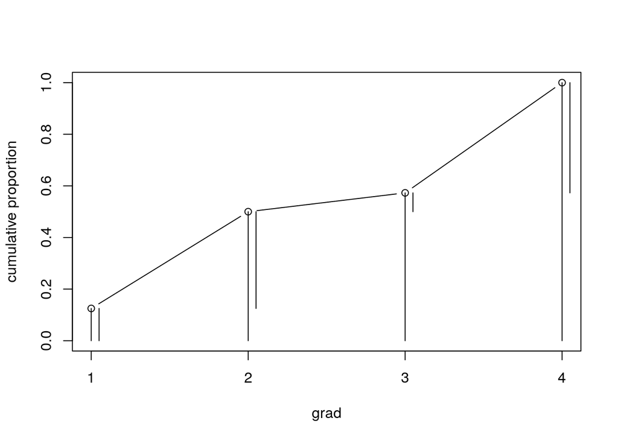

```r
plot( 1:n , cp , type="b" , xlab="grad" ,
ylab="cumulative proportion" , ylim=c(0,1), xaxt="n" )
axis(1, at = 1:n)
segments(1:n,0,1:n,cp)
for(i in 1:n){
  segments(i+0.05,c(0,cp)[i],i+0.05,cp[i])
  }
```

## 12M3.

Given: Zero-inflated Poisson (ZIPoisson).

Want: Zero-inflated binomial.

Sol.

$Pr(k=0\mid p, n) = Pr(fail\mid p) + Pr(success\mid p) \times Pr(k=0\mid n)$ $= p + (1-p)\binom{n}{0}p^0(1-p)^{n-0} = p + (1-p)^{n+1}$.

$Pr(k\mid k>0, p, n) = Pr(success\mid p) \times Pr(k\mid n)$ $= \binom{n}{k}p^k(1-p)^{n-k+1}$.

## 12H1.

Given: Hurricanes data.

Want: Poisson model with ´deaths´ and ´femininity´. Poisson model with ´deaths´. Compare. How strong is the association between femininity of name and deaths? Which storms does the model fit (retrodict) well? Which storms does it fit poorly?

Sol.:

```r
data(Hurricanes)
d <- Hurricanes
sprintf("Number of missing values: %d", sum(complete.cases(d) == FALSE))
```

```
## [1] "Number of missing values: 0"
```

```r
summary(d)
```

```
##        name         year          deaths          category      min_pressure
##  Bob     : 3   Min.   :1950   Min.   :  0.00   Min.   :1.000   Min.   : 909.0
##  Bonnie  : 2   1st Qu.:1965   1st Qu.:  2.00   1st Qu.:1.000   1st Qu.: 950.0
##  Charley : 2   Median :1985   Median :  5.00   Median :2.000   Median : 964.0
##  Cindy   : 2   Mean   :1982   Mean   : 20.65   Mean   :2.087   Mean   : 964.9
##  Danny   : 2   3rd Qu.:1999   3rd Qu.: 20.25   3rd Qu.:3.000   3rd Qu.: 982.2
##  Florence: 2   Max.   :2012   Max.   :256.00   Max.   :5.000   Max.   :1003.0
##  (Other) :79
##   damage_norm        female         femininity
##  Min.   :    1   Min.   :0.0000   Min.   : 1.056
##  1st Qu.:  245   1st Qu.:0.0000   1st Qu.: 2.667
##  Median : 1650   Median :1.0000   Median : 8.500
##  Mean   : 7270   Mean   :0.6739   Mean   : 6.781
##  3rd Qu.: 8162   3rd Qu.:1.0000   3rd Qu.: 9.389
##  Max.   :75000   Max.   :1.0000   Max.   :10.444
##
```

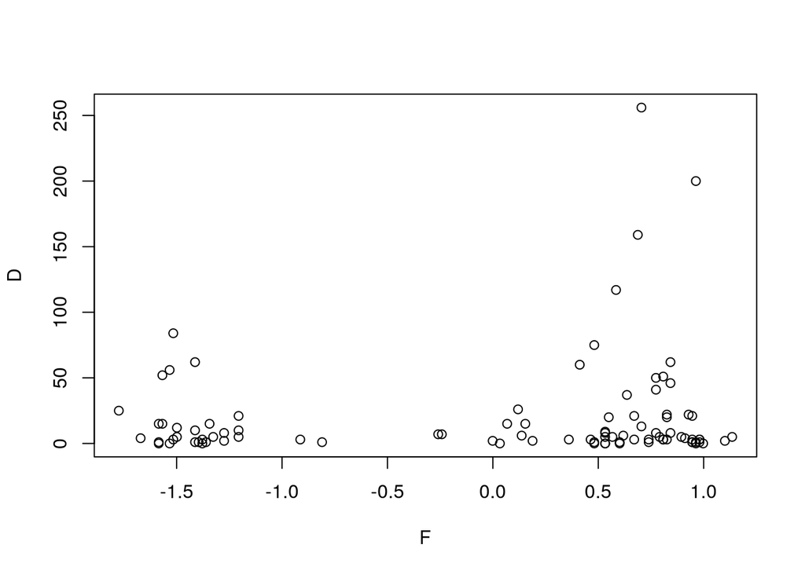

```r
d$D <- d$deaths
d$F <- standardize(d$femininity)
plot(d$D~d$F, xlab="F", ylab="D")
```

```r
set.seed(1)
# model with intercept and femininity.
m12H1a <- ulam(
    alist(
        D ~ dpois(lambda),
        log(lambda) <- a + bF*F,
        a ~ dnorm(0,5),
        bF ~ dnorm(0,1)
    ), data=d , chains=4 , cores=4, log_lik = TRUE )
```

```
## Trying to compile a simple C file
```

```r
# Sermon on priors.
set.seed(1)
m12H1a.prior <- extract.prior( m12H1a)
```

```
## Trying to compile a simple C file
```

```r
precis(m12H1a.prior)
```

[output not shown]

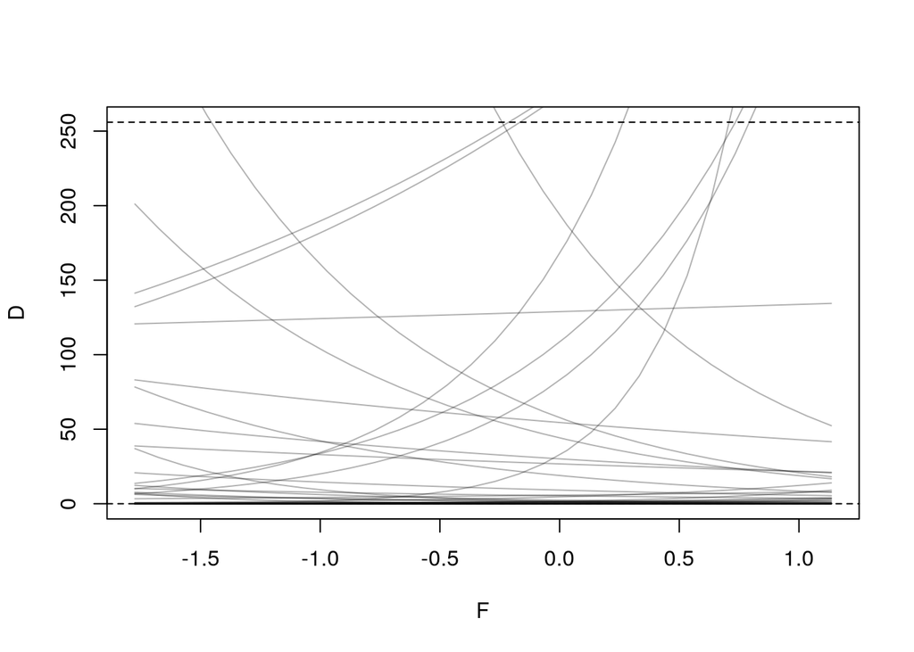

```r
plot( NULL , xlim=c(min(d$F),max(d$F)) , ylim=c(min(d$D),max(d$D)) ,xlab="F" , ylab="D" )
abline( h=min(d$deaths) , lty=2 )
abline( h=max(d$deaths) , lty=2 )

F_seq <- seq( from=min(d$F) , to=max(d$F) , length.out=30 )
mu <- link( m12H1a, post=m12H1a.prior , data=data.frame(F=F_seq) )
for ( i in 1:50 ) lines( F_seq , mu[i,] , col=col.alpha("black",0.3) )
```

```r
precis(m12H1a, depth = 2)
```

```
##         mean         sd      5.5%     94.5%    n_eff     Rhat4
## a  2.9998491 0.02355348 2.9622512 3.0374464 1194.127 0.9997193
## bF 0.2379138 0.02521600 0.1966277 0.2776839 1296.220 1.0039539
```

```r
set.seed(1)
# offset only model
m12H1b <- ulam(
    alist(
        D ~ dpois(lambda),
        log(lambda) <- a,
        a ~ dnorm(0,5)
    ), data=d , chains=4 , cores=4, log_lik = TRUE )
```

```
## Trying to compile a simple C file
```

```r
precis(m12H1a, depth = 2)
```

```
##         mean         sd      5.5%     94.5%    n_eff     Rhat4
## a  2.9998491 0.02355348 2.9622512 3.0374464 1194.127 0.9997193
## bF 0.2379138 0.02521600 0.1966277 0.2776839 1296.220 1.0039539
```

```r
precis(m12H1b, depth = 2)
```

```
##       mean         sd     5.5%    94.5%    n_eff    Rhat4
## a 3.028051 0.02283818 2.990347 3.061196 652.5529 1.002924
```

```r
exp(coef(m12H1a))
```

```
##        a       bF
## 20.08251  1.26860
```

```r
exp(coef(m12H1b))
```

```
##     mean
## 20.65693
```

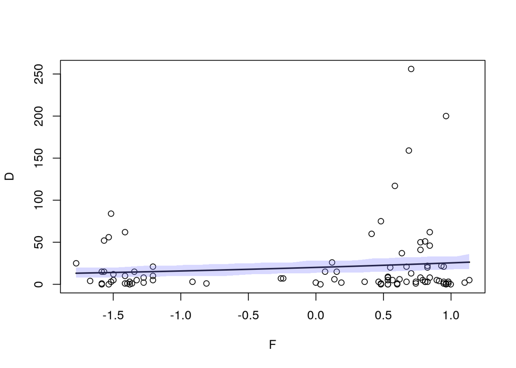

```r
set.seed(1)
plot(d$D~d$F, xlab="F", ylab="D")

mu <- link( m12H1a, data=data.frame(F=F_seq ) )
mu_mean <- apply(mu,2,mean)
lines( F_seq , mu_mean , lwd=2 )

sim.D <- sim( m12H1a, data=data.frame(F=F_seq ) )
sim.PI <- apply( sim.D , 2 , PI , prob=0.89 )
shade( sim.PI , F_seq , col=col.alpha(rangi2,0.3) )
```

```r
compare(m12H1a, m12H1b)
```

```
##            WAIC       SE    dWAIC      dSE     pWAIC       weight
## m12H1a 4413.420 1001.248  0.00000       NA 131.12655 9.999999e-01
## m12H1b 4445.592 1072.556 32.17186 137.9898  79.38065 1.032690e-07
```

```r
set.seed(1)
d$m12H1a_penalty <- WAIC(m12H1a, pointwise = TRUE)$penalty
d$m12H1a_k <- PSIS(m12H1a, pointwise = TRUE)$k
```

```
## Some Pareto k values are very high (>1). Set pointwise=TRUE to inspect individual points.
```

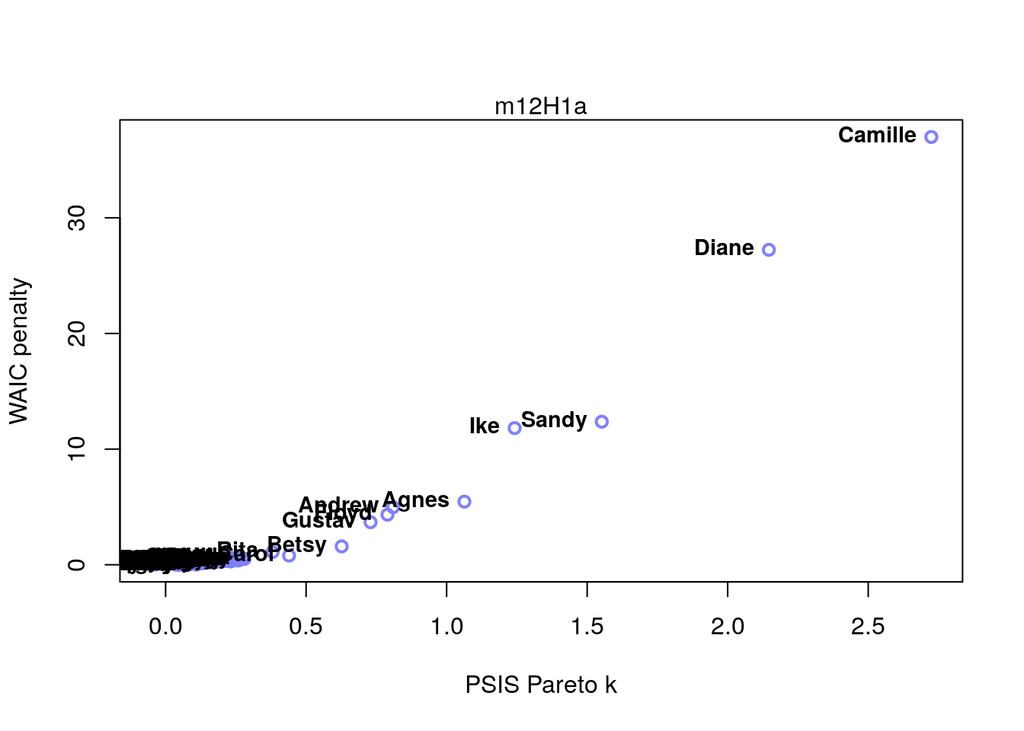

```r
plot( d$m12H1a_k , d$m12H1a_penalty , xlab="PSIS Pareto k" , xlim=c(min(d$m12H1a_k),max(d$m12H1a_k)),
    ylab="WAIC penalty" , col=rangi2 , lwd=2 )
text(d$m12H1a_penalty~d$m12H1a_k, labels=d$name, data=d, cex=0.9, font=2, pos=2)
mtext("m12H1a")
```

```r
print("Poorly fitted storms:")
```

```
## [1] "Poorly fitted storms:"
```

```r
d[d$m12H1a_k>0.5,]
```

```
##       name year deaths category min_pressure damage_norm female femininity   D
## 10   Diane 1955    200        1          987       14730      1    9.88889 200
## 24   Betsy 1965     75        3          948       20000      1    8.33333  75
## 29 Camille 1969    256        5          909       23040      1    9.05556 256
## 34   Agnes 1972    117        1          980       20430      1    8.66667 117
## 59  Andrew 1992     62        5          922       66730      0    2.22222  62
## 70   Floyd 1999     56        2          956        8130      0    1.83333  56
## 88  Gustav 2008     52        2          954        4360      0    1.72222  52
## 89     Ike 2008     84        2          950       20370      0    1.88889  84
## 92   Sandy 2012    159        2          942       75000      1    9.00000 159
##             F m12H1a_penalty  m12H1a_k
## 10  0.9630864      27.231310 2.1465956
## 24  0.4810743       1.587581 0.6266056
## 29  0.7048674      36.985650 2.7246581
## 34  0.5843644       5.459120 1.0632393
## 59 -1.4125390       4.977631 0.8095700
## 70 -1.5330421       4.331907 0.7895826
## 88 -1.5674711       3.680140 0.7292757
## 89 -1.5158260      11.816403 1.2419956
## 92  0.6876514      12.367520 1.5520269
```

## 12H2.

Given: 12H1.

Want: Fit with gamma-Poisson model. Show that the over-dispersed model no longer shows as precise a positive association between femininity and deaths, with an 89% interval that overlaps zero. Can you explain why the association diminished in strength?

Sol.:

```r
head(d)
```

```
##       name year deaths category min_pressure damage_norm female femininity  D
## 1     Easy 1950      2        3          960        1590      1    6.77778  2
## 2     King 1950      4        3          955        5350      0    1.38889  4
## 3     Able 1952      3        1          985         150      0    3.83333  3
## 4  Barbara 1953      1        1          987          58      1    9.83333  1
## 5 Florence 1953      0        1          985          15      1    8.33333  0
## 6    Carol 1954     60        3          960       19321      1    8.11111 60
##               F m12H1a_penalty   m12H1a_k
## 1 -0.0009347453      0.1808318 0.02859709
## 2 -1.6707580424      0.2507068 0.15013795
## 3 -0.9133139565      0.2296697 0.17855151
## 4  0.9458703621      0.5094295 0.28026689
## 5  0.4810742824      0.2908059 0.06802703
## 6  0.4122162926      0.7959716 0.43932991
```

```r
set.seed(1)
m12H2 <- ulam(
    alist(
        D ~ dgampois( lambda , phi ),
        log(lambda) <- a + bF*F,
        a ~ dnorm(0,5),
        bF ~ dnorm(0,1),
        phi ~ dexp(1)
    ), data=d , chains=4 ,cores=4 )
```

```
## Trying to compile a simple C file
```

```r
set.seed(1)
# Sermon on priors.
m12H2.prior <- extract.prior( m12H2)
```

```
## Trying to compile a simple C file
```

```r
precis(m12H2.prior)
```

[output not shown]

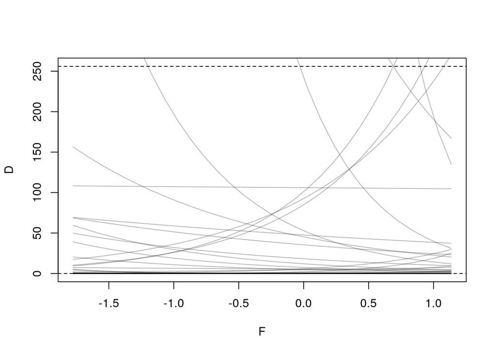

```r
plot( NULL , xlim=c(min(d$F),max(d$F)) , ylim=c(min(d$D),max(d$D)) ,xlab="F" , ylab="D" )
abline( h=min(d$D) , lty=2 )
abline( h=max(d$D) , lty=2 )

F_seq <- seq( from=min(d$F) , to=max(d$F), length.out=30 )
mu <- link( m12H2, post=m12H2.prior , data=data.frame(F=F_seq) )
for ( i in 1:50 ) lines( F_seq , mu[i,] , col=col.alpha("black",0.3) )
```

```r
precis(m12H1a)
```

```
##         mean         sd      5.5%     94.5%    n_eff     Rhat4
## a  2.9998491 0.02355348 2.9622512 3.0374464 1194.127 0.9997193
## bF 0.2379138 0.02521600 0.1966277 0.2776839 1296.220 1.0039539
```

```r
precis(m12H2)
```

```
##          mean         sd        5.5%     94.5%    n_eff     Rhat4
## a   3.0212269 0.16125244  2.78017740 3.2838091 1666.615 1.0000618
## bF  0.2072655 0.15834606 -0.04894788 0.4630534 2038.234 0.9992284
## phi 0.4526956 0.06008644  0.36216603 0.5541098 2029.249 0.9988050
```

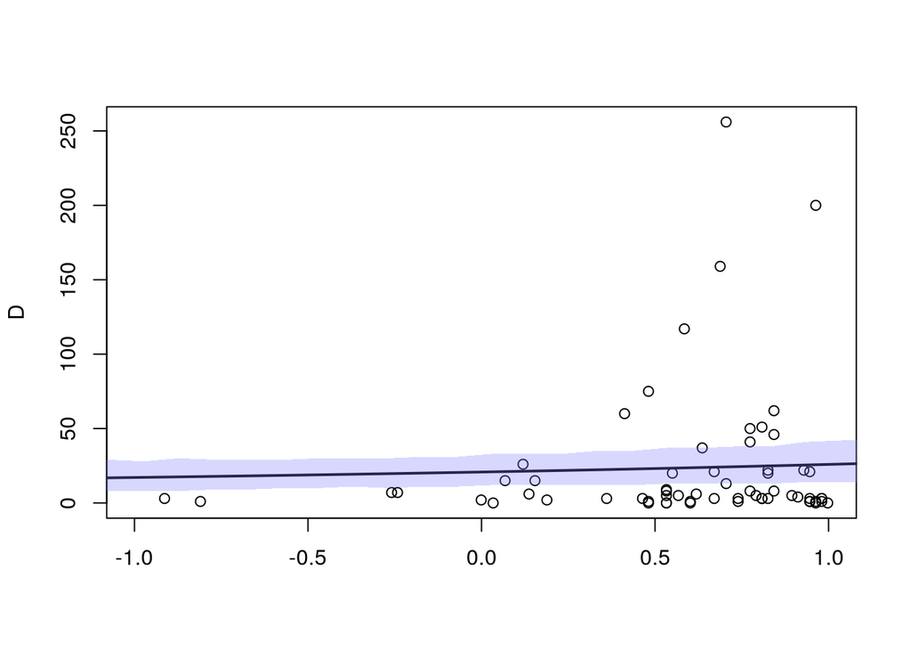

```r
set.seed(1)
plot(d$D~d$F, xlab="", ylab="D", xlim=c(min(F),max(F)))

mu <- link( m12H2, data=data.frame(F=F_seq ) )
mu_mean <- apply(mu,2,mean)
lines( F_seq , mu_mean , lwd=2 )

sim.D <- sim( m12H2, data=data.frame(F=F_seq ) )
sim.PI <- apply( sim.D , 2 , PI , prob=0.89 )
shade( sim.PI , F_seq , col=col.alpha(rangi2,0.3) )
```

## 12H3.

Given: Hurricane data.

Want: Model interaction effect with ´damage_norm´ (normalized estimate of damage in dollars) or ´min_pressure´ (minimum pressure, a measure of storm strength; low is stronger).

Sol.:

```r
summary(d)
```

```
##        name         year          deaths          category      min_pressure
##  Bob     : 3   Min.   :1950   Min.   :  0.00   Min.   :1.000   Min.   : 909.0
##  Bonnie  : 2   1st Qu.:1965   1st Qu.:  2.00   1st Qu.:1.000   1st Qu.: 950.0
##  Charley : 2   Median :1985   Median :  5.00   Median :2.000   Median : 964.0
##  Cindy   : 2   Mean   :1982   Mean   : 20.65   Mean   :2.087   Mean   : 964.9
##  Danny   : 2   3rd Qu.:1999   3rd Qu.: 20.25   3rd Qu.:3.000   3rd Qu.: 982.2
##  Florence: 2   Max.   :2012   Max.   :256.00   Max.   :5.000   Max.   :1003.0
##  (Other) :79
##   damage_norm        female         femininity           D
##  Min.   :    1   Min.   :0.0000   Min.   : 1.056   Min.   :  0.00
##  1st Qu.:  245   1st Qu.:0.0000   1st Qu.: 2.667   1st Qu.:  2.00
##  Median : 1650   Median :1.0000   Median : 8.500   Median :  5.00
##  Mean   : 7270   Mean   :0.6739   Mean   : 6.781   Mean   : 20.65
##  3rd Qu.: 8162   3rd Qu.:1.0000   3rd Qu.: 9.389   3rd Qu.: 20.25
##  Max.   :75000   Max.   :1.0000   Max.   :10.444   Max.   :256.00
##
##        F           m12H1a_penalty        m12H1a_k
##  Min.   :-1.7740   Min.   : 0.00081   Min.   :-0.05131
##  1st Qu.:-1.2748   1st Qu.: 0.12744   1st Qu.: 0.07553
##  Median : 0.5327   Median : 0.29194   Median : 0.15348
##  Mean   : 0.0000   Mean   : 1.42529   Mean   : 0.25394
##  3rd Qu.: 0.8082   3rd Qu.: 0.45928   3rd Qu.: 0.22818
##  Max.   : 1.1352   Max.   :36.98565   Max.   : 2.72466
##
```

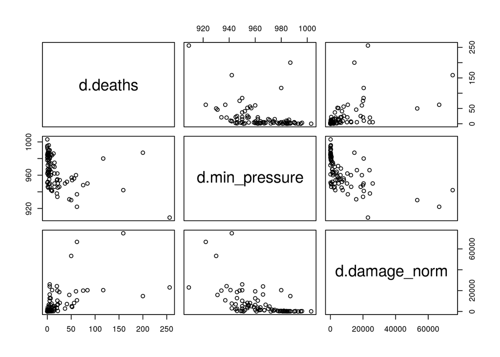

```r
d$P <- standardize(d$min_pressure)
d$C <- standardize(d$damage_norm)
#summary(d)
pairs(data.frame(d$deaths,d$min_pressure, d$damage_norm))
```

```r
# Poisson model
set.seed(1)
m12H3a <- ulam(
    alist(
        D ~ dpois(lambda),
        log(lambda) <- a + bF*F + bP*P + bC*C +bFP*F*P + bFC*F*C + bPC*P*C + bFPC*F*P*C,
        a ~ dnorm(0,5),
        c(bF, bP, bC, bFP, bFC, bPC, bFPC) ~ dnorm(0,1)
    ), data=d , chains=4 , cores=4, log_lik=TRUE)
```

```
## Trying to compile a simple C file
```

```r
set.seed(1)
#Gamma poisson
m12H3b <- ulam(
    alist(
        D ~ dgampois( lambda , phi ),
        log(lambda) <- a + bF*F + bP*P + bC*C +bFP*F*P + bFC*F*C + bPC*P*C + bFPC*F*P*C,
        a ~ dnorm(0,5),
        c(bF, bP, bC, bFP, bFC, bPC, bFPC) ~ dnorm(0,1),
        phi ~ dexp(1)
    ), data=d , chains=4 , cores=4, log_lik=TRUE)
```

```
## Trying to compile a simple C file
```

```r
p12H3a <- precis(m12H3a)
p12H3b <- precis(m12H3b)

orderByRowname <-function(df){
  return(df[ order(row.names(df)), ])
}

print(orderByRowname(p12H3a))
```

```
##             mean         sd        5.5%      94.5%     n_eff     Rhat4
## a     2.73296725 0.03236028  2.68281019  2.7859891 1292.5826 1.0006194
## bC    0.84464843 0.04679932  0.77087066  0.9201036  936.0225 1.0070959
## bF    0.24634165 0.03495087  0.19321043  0.3036196 1121.2422 1.0005329
## bFC   0.32649611 0.05990781  0.23040522  0.4281296  938.6508 0.9993071
## bFP   0.03649639 0.04029452 -0.02847094  0.1016783  970.8740 1.0050364
## bFPC  0.21478012 0.02962431  0.16809900  0.2634505 1133.8694 0.9988898
## bP   -0.67799298 0.03614995 -0.73588632 -0.6213110 1038.8871 1.0002818
## bPC   0.46462548 0.02799667  0.42121695  0.5089564 1033.8475 1.0070742
```

```r
print(orderByRowname(p12H3b))
```

```
##            mean        sd        5.5%      94.5%     n_eff     Rhat4
## a     2.6665385 0.1399222  2.45499017  2.8960072 1421.2143 0.9992119
## bC    1.1866733 0.2766869  0.75175757  1.6366618  754.9204 1.0035345
## bF    0.1356918 0.1313930 -0.07238629  0.3482744 1404.4904 1.0025511
## bFC   0.5624116 0.3039706  0.06398806  1.0583423  745.1946 1.0026113
## bFP   0.1648659 0.1999637 -0.14010865  0.4953475  643.9428 1.0068207
## bFPC  0.2300836 0.1419545  0.00801534  0.4594347  951.0400 1.0019514
## bP   -0.6531608 0.1750122 -0.94270404 -0.3755110  809.4451 1.0066526
## bPC   0.4705491 0.1413572  0.24497894  0.6913717  725.7979 1.0012250
## phi   0.8619296 0.1375065  0.65908258  1.0955559 1115.8553 0.9992483
```

```r
compare(m12H3a, m12H3b)
```

```
##             WAIC         SE    dWAIC      dSE     pWAIC weight
## m12H3b  654.1278   34.17392    0.000       NA  11.12885      1
## m12H3a 3336.7810 1156.64673 2682.653 1141.646 615.09957      0
```

```r
exp(coef(m12H3b)['bF'])
```

```
##       bF
## 1.145329
```

- ´bP´ is negative, meaning the stronger the strom the more deaths, as expected.
- ´bC´ has the highst value amount coefficients, meaning damage costs are highly correlated with deaths.
- According to WAIC, the Gamma-Poisson makes better preditions.
- Femininity is weakly correated with death in the Gamma-Poisson model. An increase by 1 in femininity increases the number of deaths by about 1 +-1.

## 12H4.

Given: Hurricane data.

Claim: The logarithm of storm strength is what matters.

Want: Compare a model that uses ´log(damage_norm)´ to a model that uses ´damage_norm´ directly. Compare their DIC/WAIC values as well as their implied predictions. What do you conclude?

Sol.:

```r
d$lC <- standardize(log(d$damage_norm))
```

```r
set.seed(1)
m12H4 <- ulam(
    alist(
        D ~ dgampois( lambda , phi ),
        log(lambda) <- a + bF*F + bP*P + bC*lC +bFP*F*P + bFC*F*lC + bPC*P*lC + bFPC*F*P*lC,
        a ~ dnorm(0,5),
        c(bF, bP, bC, bFP, bFC, bPC, bFPC) ~ dnorm(0,1),
        phi ~ dexp(1)
    ), data=d , chains=4 , cores=4, log_lik=TRUE)
```

```
## Trying to compile a simple C file
```

```r
p12H4 <- precis(m12H4)
print(orderByRowname(p12H3b))
```

```
##            mean        sd        5.5%      94.5%     n_eff     Rhat4
## a     2.6665385 0.1399222  2.45499017  2.8960072 1421.2143 0.9992119
## bC    1.1866733 0.2766869  0.75175757  1.6366618  754.9204 1.0035345
## bF    0.1356918 0.1313930 -0.07238629  0.3482744 1404.4904 1.0025511
## bFC   0.5624116 0.3039706  0.06398806  1.0583423  745.1946 1.0026113
## bFP   0.1648659 0.1999637 -0.14010865  0.4953475  643.9428 1.0068207
## bFPC  0.2300836 0.1419545  0.00801534  0.4594347  951.0400 1.0019514
## bP   -0.6531608 0.1750122 -0.94270404 -0.3755110  809.4451 1.0066526
## bPC   0.4705491 0.1413572  0.24497894  0.6913717  725.7979 1.0012250
## phi   0.8619296 0.1375065  0.65908258  1.0955559 1115.8553 0.9992483
```

```r
print(orderByRowname(p12H4))
```

```
##              mean        sd       5.5%     94.5%     n_eff     Rhat4
## a     2.214220719 0.1543408  1.9706199 2.4700077  945.7783 1.0024339
## bC    1.370018004 0.2019480  1.0492366 1.6929940  923.8188 1.0003808
## bF    0.033275563 0.1488174 -0.2041559 0.2730045  976.9349 1.0031281
## bFC   0.160361889 0.2236688 -0.2045248 0.5187991  929.5437 1.0042834
## bFP   0.007633851 0.2106203 -0.3225607 0.3540539  945.8501 1.0045424
## bFPC -0.018247003 0.1307853 -0.2208576 0.1907356 1093.7870 1.0023356
## bP   -0.011259305 0.2009454 -0.3271994 0.3136009  928.1622 1.0023405
## bPC  -0.087044264 0.1367357 -0.3025481 0.1301956 1057.1118 1.0025754
## phi   1.003806965 0.1653674  0.7676949 1.2793364 1330.6343 0.9996451
```

```r
compare(m12H3b, m12H4)
```

```
##            WAIC       SE   dWAIC      dSE    pWAIC      weight
## m12H4  640.7960 32.27260  0.0000       NA 10.60082 0.998728009
## m12H3b 654.1278 34.17392 13.3318 10.80912 11.12885 0.001271991
```

- According to WAIC, the model with the log of ´damage_norm´ makes better predictions.
- Everything except the log of ´damage_norm´ has almost no influence on the number of death.

## 12H5.

Given: Trolley data.

Want: Are Women more or less bothered by contact than men?

```r
data(Trolley)
d <- Trolley

head(d)
```

```
##    case response order     id age male           edu action intention contact
## 1 cfaqu        4     2 96;434  14    0 Middle School      0         0       1
## 2 cfbur        3    31 96;434  14    0 Middle School      0         0       1
## 3 cfrub        4    16 96;434  14    0 Middle School      0         0       1
## 4 cibox        3    32 96;434  14    0 Middle School      0         1       1
## 5 cibur        3     4 96;434  14    0 Middle School      0         1       1
## 6 cispe        3     9 96;434  14    0 Middle School      0         1       1
##   story action2
## 1   aqu       1
## 2   bur       1
## 3   rub       1
## 4   box       1
## 5   bur       1
## 6   spe       1
```

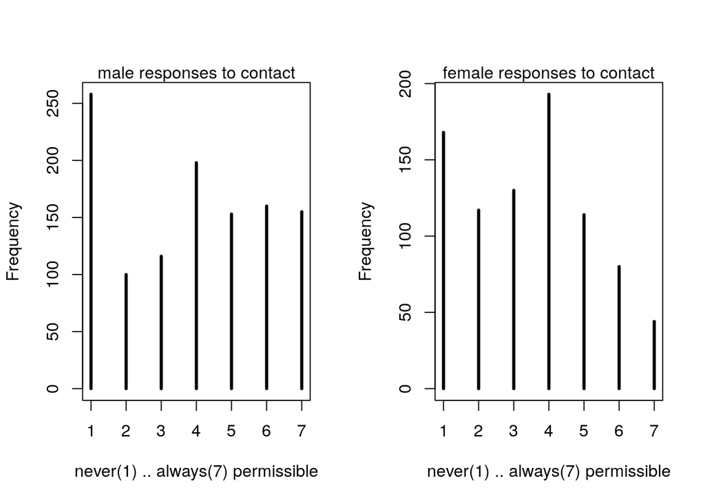

```r
par(mfrow=c(1,2))
simplehist(d[d$male==1 & d$contact ==1, c("response")], xlab="never(1) .. always(7) permissible")
mtext("male responses to contact")

simplehist(d[d$male==0 & d$contact ==1, c("response")], xlab="never(1) .. always(7) permissible")
mtext("female responses to contact")
```

```r
dat <- list(
    R = d$response,
    A = d$action,
    I = d$intention,
    C = d$contact,
    M = d$male)
str(dat)
```

```
## List of 5
##  $ R: int [1:9930] 4 3 4 3 3 3 5 4 4 4 ...
##  $ A: int [1:9930] 0 0 0 0 0 0 1 1 1 1 ...
##  $ I: int [1:9930] 0 0 0 1 1 1 0 0 0 0 ...
##  $ C: int [1:9930] 1 1 1 1 1 1 0 0 0 0 ...
##  $ M: int [1:9930] 0 0 0 0 0 0 0 0 0 0 ...
```

```r
m12H5a <- ulam(
    alist(
        R ~ dordlogit( phi , cutpoints ),
        phi <- bA*A + bC*C + BI*I +bM*M + bCM*C*M ,
        BI <- bI + bIA*A + bIC*C ,
        c(bA,bI,bC,bM,bIA,bIC,bCM) ~ dnorm( 0 , 0.5 ),
        cutpoints ~ dnorm( 0 , 1.5 )
    ), data=dat , chains=4 , cores=4, log_lik = TRUE )
```

```
## Trying to compile a simple C file
```

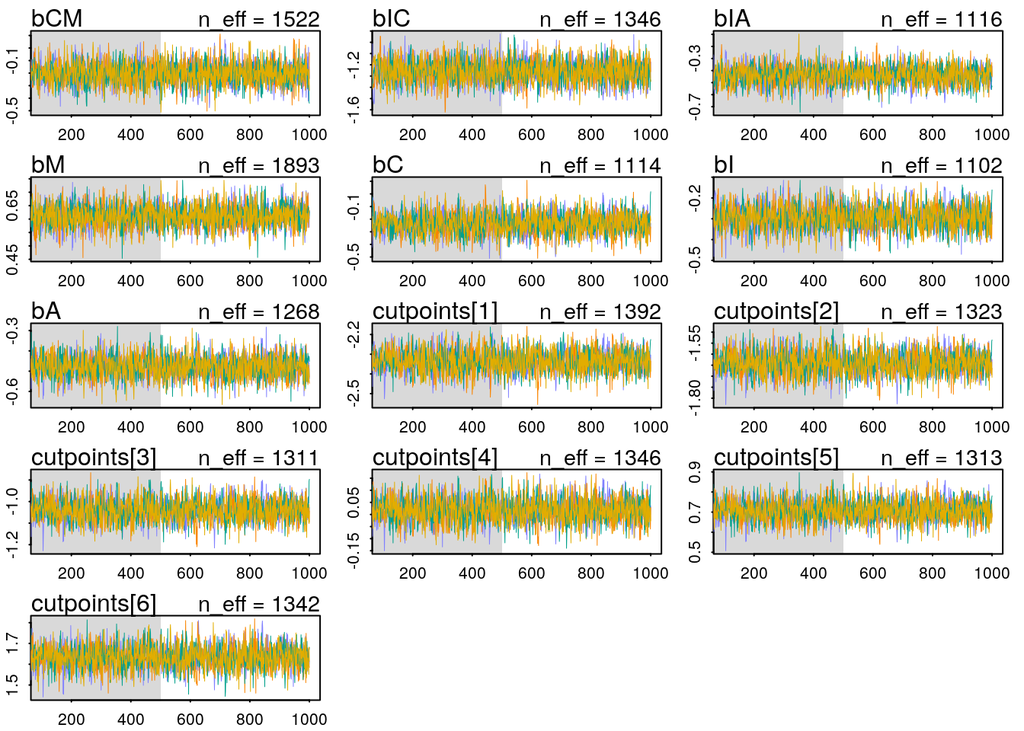

```r
traceplot( m12H5a )
```

```r
#dat$m <- d$male + 1
#m12H5b <- ulam(
#    alist(
#        R ~ dordlogit( phi , cutpoints ),
#        phi <- bA[m]*A + bC[m]*C + BI*I ,
#        BI <- bI[m] + bIA[m]*A + bIC[m]*C ,
#        c(bA[m],bI[m],bC[m],bIA[m],bIC[m]) ~ dnorm( 0 , 0.5 ),
#        cutpoints ~ dnorm( 0 , 1.5 )
#    ), data=dat , chains=4 , cores=4, log_lik = TRUE )

# Index did not compile because:
#SYNTAX ERROR, MESSAGE(S) FROM PARSER:
#Dimension declaration requires expression denoting integer; found type=int[ ]
# error in 'model4d491d55f2f9_bd64f564bd226da65a35f8cc707779e5' at line 10, column 13
#  -------------------------------------------------
#     8: }
#     9: parameters{
#    10:     real bIC[m];
#                    ^
#    11:     real bIA[m];
#  -------------------------------------------------
```

```r
precis( m12H5a, depth=2 )
```

```
##                     mean         sd        5.5%       94.5%    n_eff     Rhat4
## bCM          -0.20570963 0.08962635 -0.34278663 -0.06343169 1521.983 0.9994772
## bIC          -1.25948884 0.10109049 -1.42453730 -1.10013605 1345.979 1.0001110
## bIA          -0.43860563 0.07794108 -0.56513245 -0.31738938 1115.910 1.0010677
## bM            0.61171680 0.04054301  0.54863147  0.67818815 1892.945 1.0004112
## bC           -0.23360795 0.08420947 -0.36726161 -0.09575792 1114.177 1.0001395
## bI           -0.29434148 0.05645411 -0.38403357 -0.20338504 1101.649 1.0007465
## bA           -0.47788492 0.05400261 -0.56443405 -0.39108402 1268.412 1.0005408
## cutpoints[1] -2.33590425 0.05467887 -2.42106627 -2.24672388 1391.696 1.0017530
## cutpoints[2] -1.64113873 0.05069585 -1.71723293 -1.55933837 1322.980 1.0012792
## cutpoints[3] -1.03980790 0.04939679 -1.11817072 -0.95836509 1310.521 1.0008478
## cutpoints[4]  0.01769233 0.04905063 -0.05701617  0.09945392 1346.269 1.0010965
## cutpoints[5]  0.70702027 0.05083309  0.63039904  0.79061853 1312.933 1.0016347
## cutpoints[6]  1.63355271 0.05449669  1.54886481  1.72440862 1341.877 1.0002660
```

- ´bM´ is positive, meaning men are less bothered, overall.
- ´bCM´ is negative, meaning the men are relatively more bothered by contact.
- ´bM´ is greater than ´bCM´, meaning by going by higher numbers, men are less bothered by contact.